# Week8

#### Note:

All code is written in Python 3 with the numpy package.

### 13.5.1

**(a)** Let $u_0 = u(0), u_4 = u(1),$ and let $u_1, u_2, u_3$ be the approximations to $u(1/4), u(2/4), u(3/4)$ respectively. We have $$u'(hi)\approx \frac{u_{i+1} - u_{i-1}}{2h}$$ and $$u''(hi)\approx \frac{u_{i+1}-2u_i+u_{i-1}}{h^2}$$ So, $$(hi)^2 = u''(hi) + 2(hi)u'(hi) - (hi)^2u(hi) \approx \frac{u_{i+1}-2u_i+u_{i-1}}{h^2} + i(u_{i+1}-u_{i-1}) - h^2i^2u_i$$

The difference equations are

$$u_0 = 1$$$$\frac{u_0-2u_1+u_2}{h^4} + \frac{u_2-u_0}{h^2} - u_1 = 1$$$$\frac{u_1-2u_2+u_3}{h^4} + 2\frac{u_3-u_1}{h^2} - 4u_2 = 4$$$$\frac{u_2-2u_3+u_4}{h^4} + 3\frac{u_4-u_2}{h^2} - 9u_3 = 9$$$$u_4 = 1$$

**(b)** This one is nearly identical to the above, we just replace $u_{i+1}-u_{i-1}$ with $2(u_{i}-u_{i-1})$. The difference equations are $$u_0 = 1$$ $$\frac{u_0-2u_1+u_2}{h^4} + 2\frac{u_1-u_0}{h^2} - u_1 = 1$$ $$\frac{u_1-2u_2+u_3}{h^4} + 4\frac{u_2-u_1}{h^2} - 4u_2 = 4$$ $$\frac{u_2-2u_3+u_4}{h^4} + 6\frac{u_3-u_2}{h^2} - 9u_3 = 9$$ $$u_4 = 1$$

**(c)** We have $$\frac{u_2-2u_1+u_0}{h^2}\approx u''(1/4)\approx \frac{u'(2/4) - u'(0)}{2h}\approx \frac{\frac{u_3-u_1}{2h} - u'(0)}{2h}$$ therefore $$u'(0)\approx \frac{u_3 - 4u_2 + 7u_1 - 4u_0}{4h}$$ Similarly, $$u'(1)\approx \frac{u_1 - 4u_2 + 7u_3 - 4u_4}{4h}$$

The difference equations are

$$u_0 + \frac{u_3 - 4u_2 + 7u_1 - 4u_0}{4h} = 1$$$$\frac{u_0-2u_1+u_2}{h^4} + \frac{u_2-u_0}{h^2} - u_1 = 1$$$$\frac{u_1-2u_2+u_3}{h^4} + 2\frac{u_3-u_1}{h^2} - 4u_2 = 4$$$$\frac{u_2-2u_3+u_4}{h^4} + 3\frac{u_4-u_2}{h^2} - 9u_3 = 9$$$$u_4 + \frac{u_1 - 4u_2 + 7u_3 - 4u_4}{4h} = \frac{-1}2$$

### 13.5.2

**(a)**

We have $$\frac{d}{dx}\left((1+x^2)\frac{du}{dx}\right) = 2xu' + (1+x^2)u''$$ so $$f(x_i)\approx x_i\cdot \frac{u_{i+1}-u_{i-1}}{h} + (1+x_i^2)\cdot \frac{u_{i+1}-2u_i+u_{i}}{h^2}$$ $$\Longleftrightarrow$$ $$i(u_{i+1}-u_{i-1}) + \frac{u_{i+1} - 2u_i+u_{i-1}}{h^2} + i^2(u_{i+1} - 2u_i+u_{i-1}) - f(x_i)\approx 0$$ $$\Longleftrightarrow$$ $$\left(i^2+i+\frac1{h^2}\right)u_{i+1} - \left(2i^2+\frac{2}{h^2}\right)u_i + \left(i^2-i+\frac{1}{h^2}\right)u_{i-1} - f(x_i)\approx 0$$ for $0 < i < n = \frac1h$ and $x_i = ih$.

On the left endpoint we have $$u_0 = 1$$ and on the right we have $$0 = u'_n\approx \frac{u_{n}-u_{n-1}}{h}.$$

The difference equations are: $$u_0 = 1$$ $$u_{n}-u_{n-1} = 0$$ $$\left(i^2+i+\frac1{h^2}\right)u_{i+1} - \left(2i^2+\frac{2}{h^2}\right)u_i + \left(i^2-i+\frac{1}{h^2}\right)u_{i-1} = f(x_i)$$

**(b)** This is written in Python, not MATLAB:

```
0.015786867317689857
```

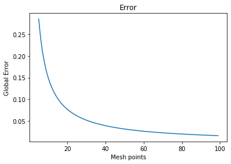

```python
import numpy as np
import matplotlib.pyplot as plt

def f(x):
    return 2*(3*x**2 - 2*x + 1)

def u_exact(x):
    return (1-x)**2

def solve(n):
    h = 1/n

    A = []
    b = []

    # Left point:
    row = np.zeros(n+1)
    row[0] = 1
    A.append(row); b.append(1)

    # Right point:
    row = np.zeros(n+1)
    row[-1] = 1; row[-2] = -1
    A.append(row); b.append(0)

    # Middle points:
    for i in range(1, n):
        row = np.zeros(n+1)
        row[i-1] = i**2 - i + n**2
        row[i] = -2*(i**2 + n**2)
        row[i+1] = i**2 + i + n**2
        A.append(row); b.append(f(i*h))

    A = np.array(A)
    u = np.linalg.inv(A) @ b
    return u

e = []

ns = list(range(5, 100))

for n in ns:
    x = np.array([i/n for i in range(n+1)])
    correct = u_exact(x)
    u = solve(n)
    #print(u)
    #print(correct)
    error = max(abs(u - correct))
    #print(error)
    e.append(error)

e = np.array(e)
plt.plot(ns, e)
plt.title("Error")
plt.ylabel("Global Error")
plt.xlabel("Mesh points")
```

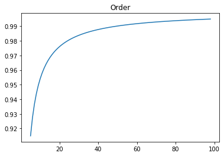

```python
log_e = np.log(e)
log_n = np.log(ns)

plt.plot(ns[:-1], (log_e[1:] - log_e[:-1])/(log_n[:-1] - log_n[1:]))
plt.title("Order")
pass
```

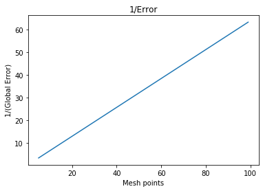

```python
plt.plot(ns, 1/e)
plt.title("1/Error")
plt.ylabel("1/(Global Error)")
plt.xlabel("Mesh points")
```

The order of my method is first order. This is easiest to see from the last graph where I plot $\frac{1}{\tau_n}$ where $\tau_n$ is the global error with $n$ meshpoints. It is only first order rather than second due to how I treated the right most endpoint, where I used a one-sided approximation for $u'$ instead of a centered one.

### 6.2 (Linfield & Penny)

I assume the problem is to use the shooting method to solve the boundary value equation

$$x^2y'' - 6y = 0; y(1)=1, y(2) = 1$$

Or equivalently,

$$y' = z$$$$z' = \frac{6y}{x^2}$$

I start with two points $(s_1, y_1), (s_2, y_2)$ where each $s$ is a random guess for $y'(1)$. and $y$ is the estimated value of $y(2)$ (using the Runge-Kutta as an ODE solver). Then I draw a line between the two points and find the value of $s_3$ so that the point $(s_3, y)$ has $y=1$.

This line has equation

$$y = \frac{y_2-y_1}{s_2-s_1}x + \frac{y_1s_2-y_2s_1}{s_2-s_1}$$

so $$s_3 = \frac{1 - \frac{y_1s_2-y_2s_1}{s_2-s_1}}{\frac{y_2-y_1}{s_2-s_1}} =\frac{s_2-s_1 + y_2s_1 - y_1s_2}{y_2-y_1}$$

I replace the worse value of $s_1$ and $s_2$ with $s_3$, and repeat this process until I get a good solution.

Code follows (in Python + Scipy):

```python
from scipy.integrate import ode
from scipy.interpolate import interp1d

def f(x, yz):
    return [yz[1], 6*yz[0]/x**2]

solver = ode(f).set_integrator('dopri5')

def solve(s, h=1e-3):
    t = 1
    solver.set_initial_value([1, s], t)
    while abs(t-2) > h/2:
        t += h
        y, z = solver.integrate(t)
    return y

s1, s2 = 1, 2
y1, y2 = solve(s1), solve(s2)

error = min(abs(y1-1), abs(y2-1))

if abs(y1-1) > abs(y2-1):
    s = s2
    y = y2
else:
    s = s1
    y = y1

iterations = 0

while error > 0.1:
    iterations += 1
    if abs(y1-1) > abs(y2-1):
        s1 = (s2-s1+s1*y2 - s2*y1)/(y2-y1)
        y1 = solve(s1)
        s = s2
        y = y2
        error = abs(y2-1)
    else:
        s2 = (s2-s1+s1*y2 - s2*y1)/(y2-y1)
        y2 = solve(s2)
        s = s1
        y = y1
        error = abs(y1-1)

print(f"Took {iterations} iterations")
print(f"y'(1) = {s} --> y(2) = {y}")
print(f"error = {error}")
```

```
Took 2 iterations
y'(1) = -1.516129032258011 --> y(2) = 0.9999999999999813
error = 1.865174681370263e-14
```

It only takes two iterations no matter the starting points because of how simple the differential equation is.

### #4

**(a)** We have $\frac{1}{\delta x} = 5$, so

$$\frac{d}{dt}u_j(t) = 25(u_{j+1}(t) - 2u_j(t) + u_{j-1}(t)) + 1$$

As $u_0(t) = u_5(t) = 0$ it can be written as $$u' = 25\begin{bmatrix}-2 & 1 & 0 & 0 \\ 1 & -2 & 1 & 0\\ 0 & 1 & -2 & 1\\ 0 & 0 & 1 & -2\\ \end{bmatrix}u + \begin{bmatrix}1\\ 1\\ 1\\ 1\end{bmatrix}$$

where $u = \begin{bmatrix}u_1\\ u_2\\ u_3\\ u_4\end{bmatrix}$.

**(b)** The eigenvalues of that matrix are $$\lambda_i = -2\left[1-\cos\left(\frac{i\pi}{5}\right)\right]\cdot 25$$ for $i=1, 2, 3, 4$.

If we used $n$ subintervals instead of just $5$, the eigenvalues would be $$\lambda_i = -2\left[1-\cos\left(\frac{i\pi}{n}\right)\right]\cdot n^2$$

The condition number of the matrix is $$\sqrt{\frac{\lambda_{n-1}}{\lambda_1}}\approx \sqrt{\frac{-2n^2\left(2-\frac{\pi^2}{2n^2}\right)}{-2n^2\cdot\frac{\pi^2}{2n^2}}} = \sqrt{\frac{4n^2 - \pi^2}{\pi^2}}.$$

by expanding the Maclaurin Series for $\cos x$. As $n$ grows large this is asymptotically equivalent to

$$\frac{2n}{\pi},$$

and so the condition number grows very large, meaning the system becomes stiff.

**(c)**

If we have function $$y' = \lambda y$$ Heun's method would give us $$y_{n+1} = y_n + \frac{h}{2}\left[\lambda y_n + h\lambda(y_n + \lambda y_n)\right] = \left[1+h\lambda+\frac{(h\lambda)^2}{2}\right]y_n.$$

So $y_n$ is a geometric sequence with common factor $$1+z+\frac{z^2}{2},$$ which we want that to be less than $1$ (where $z=h\lambda$). Therefore, $$\frac{z^2}2+z+1\le 1\implies z^2+2z\le 0\implies -2\le z \le 0$$

Now, our function $u$ defined in part *(a)* is of the form $$u' = \sum e^{\lambda_i}c_i$$ where $c_i$'s are different vectors, so if we choose a step size that is stable for every function $$y' = \lambda_i y$$ then it will also be stable for our function $u$. Note that each $\lambda_i < 0$ so the inequality becomes

$$-\frac{2}{\lambda_i}\ge h\ge 0,$$

and so the largest step size we can use is $$h=\frac{2}{\lambda_{\text{min}}} = \frac{1}{25\left[1+\cos\left(\frac{\pi}{5}\right)\right]}\approx 0.022$$

**(d)** Now for the code to implement this:

```python
A = np.array([[-2, 1, 0, 0],
              [1, -2, 1, 0],
              [0, 1, -2, 1],
              [0, 0, 1, -2]]) * 25

def u_prime(u):
    return A @ u + 1

# Apply Heun's method to get u(10)
h = 0.022
t = 0
x = np.linspace(0, 1, 6)
u = x-x**2
u = u[1:-1]
while abs(t - 10) > h/2:
    t += h
    up = u_prime(u)
    #print(u)#, up, u_prime(u+h*up))
    u += 1/2*h*(up + u_prime(u+h*up))

print(f"u(0.5, 10) = {round(u[2], 2)}")
```

```
u(0.5, 10) = 0.12
```

Notice that if we just slightly increase the step size (from $0.022$ to $0.024$) it becomes terribly unstable:

```python
h = 0.024
t = 0
x = np.linspace(0, 1, 6)
u = x-x**2
u = u[1:-1]
while abs(t - 10) > h/2:
    t += h
    up = u_prime(u)
    #print(u)#, up, u_prime(u+h*up))
    u += 1/2*h*(up + u_prime(u+h*up))

print(f"u(0.5, 10) = {u[2]}")
```

```
u(0.5, 10) = 240335090975214.03
```